# US State Chropleths

You can create a choropleth of US States with the function `state_choropleth`:

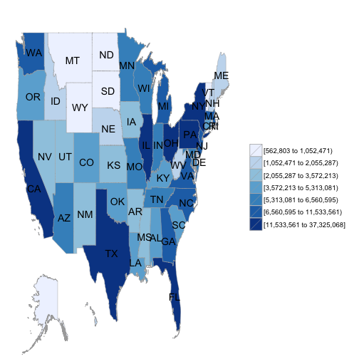

```r
library(choroplethr)

?df_pop_state
data(df_pop_state)

?state_choropleth
state_choropleth(df_pop_state)
```

As demonstrated above, the only required parameter to `state_choropleth` is a data.frame. You can see the optional parameters by typing `?state_choropleth`.

# Data Requirements

The data.frame that you provide to `state_choropleth` must have one column named “region” and one column named “value”. Your entries for “region” must **exactly** match how regions are named in the map which choroplethr uses. These names are defined in the object `state.regions`:

```r
library(choroplethrMaps)

?state.regions
data(state.regions)
head(state.regions)
```

```
##       region abb fips.numeric fips.character
## 1     alaska  AK            2             02
## 2    alabama  AL            1             01
## 3   arkansas  AR            5             05
## 4    arizona  AZ            4             04
## 5 california  CA            6             06
## 6   colorado  CO            8             08
```

In order to use choroplethr, you must use the naming convention in the “region” column of state.regions. That is, you must use full names in all lowercase letters.

# Exploring Data

The `state_choropleth` function provides two parameters to facilitate exploring data: `buckets` and `zoom`. buckets defaults to 7, which means that there are 7 colors, and an equal number of states in each color. Valid values for buckets are integers betwen 1 and 7. If buckets is 1 then a continuous scale will be used. zoom defaults to NULL, which means that all states are shown. You can set it to be a vector of valid regions.

As an example, here is how you can use choroplethr to show the population of US States on the West Coast.

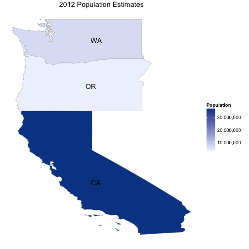

```r
state_choropleth(df_pop_state,
                 title   = "2012 Population Estimates",
                 legend  = "Population",
                 buckets = 1,
                 zoom    = c("california", "washington", "oregon"))
```

# Advanced Options

Any customization outside the optional parameters presented above will require you to create a `StateChoropleth` object. choroplethr uses R6 to take advantage of object-oriented programming. Here is an example of using the `ggplot2_scale` on the base Choropleth object to customize the palette used.

This dataset is the 2012 US Presidential Election results. Normally in this map Democratic states appear blue and Republican states appear red.

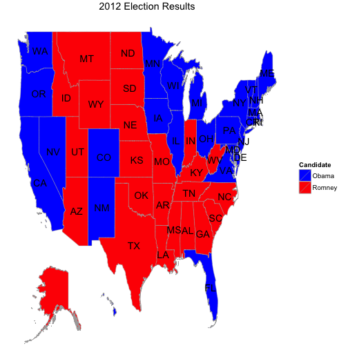

```r
library(ggplot2)

?df_president
data(df_president)

choro = StateChoropleth$new(df_president)
choro$title = "2012 Election Results"
choro$ggplot_scale = scale_fill_manual(name="Candidate", values=c("blue", "red"), drop=FALSE)
choro$render()
```

For additional options on the `StateChoropleth` object, please see the choroplethr [source code](https://github.com/trulia/choroplethr).

**Note:** Care must be taken when manually setting the scale on `StateChoropleth` objects. In particular, choroplethr uses ggplot2 custom annotations to render Alaska and Hawaii as insets. This means that the scales of the insets and the main map will only be the same if you do the following

1. for discrete scales, pass `drop=FALSE` to the scale (as above).
2. for continuous scales, pass `limits` which encompass the minimum and maximum values for the entire dataset.